# Advanced Machine Learning - Homework 2

Cyprien NIELLY

## Ex. 1 — ImageNet

*1. What is ImageNet?*

ImageNet is a massive database of human-annotated images. It contains more than 15 million images, and those are labeled through crowdsourcing. It is used in Machine Learning to compare progress in automatic image detection.

*2. How many different kinds of cheese can you find in ImageNet?*

There are **30 different kinds of cheese** on ImageNet.

*3. What is the best classifier on ImageNet and what is its error rate?*

The best classifier on ImageNet so far is the **SENet (Squeeze and Excitation Networks)**. It won the 2017 ImageNet Classification Task with a top-5 error of **2.251%**, a 25% relative improvement of the winning entry of 2016.

## Ex. 2 — Build an image recognition system

Build an image recognition system for a 1000 everyday object categories (ImageNet ILSVRC) using Keras and TensorFlow.

*1. Install keras*

```r
library(keras)
#install_keras()
```

*2. Define ResNet50 as you model and check its architecture*

```r
model <- application_resnet50(weights = 'imagenet')
summary(model)
```

```
________________________________________________________________________________________________________________
Layer (type)                        Output Shape             Param #       Connected to
================================================================================================================
input_13 (InputLayer)               (None, 224, 224, 3)      0
________________________________________________________________________________________________________________
conv1_pad (ZeroPadding2D)           (None, 230, 230, 3)      0             input_13[0][0]
________________________________________________________________________________________________________________
conv1 (Conv2D)                      (None, 112, 112, 64)     9472          conv1_pad[0][0]
________________________________________________________________________________________________________________
bn_conv1 (BatchNormalization)       (None, 112, 112, 64)     256           conv1[0][0]
________________________________________________________________________________________________________________
activation_170 (Activation)         (None, 112, 112, 64)     0             bn_conv1[0][0]
________________________________________________________________________________________________________________
max_pooling2d_4 (MaxPooling2D)      (None, 55, 55, 64)       0             activation_170[0][0]
________________________________________________________________________________________________________________
res2a_branch2a (Conv2D)             (None, 55, 55, 64)       4160          max_pooling2d_4[0][0]
________________________________________________________________________________________________________________
bn2a_branch2a (BatchNormalization)  (None, 55, 55, 64)       256           res2a_branch2a[0][0]
________________________________________________________________________________________________________________
activation_171 (Activation)         (None, 55, 55, 64)       0             bn2a_branch2a[0][0]
________________________________________________________________________________________________________________
res2a_branch2b (Conv2D)             (None, 55, 55, 64)       36928         activation_171[0][0]
________________________________________________________________________________________________________________
bn2a_branch2b (BatchNormalization)  (None, 55, 55, 64)       256           res2a_branch2b[0][0]
________________________________________________________________________________________________________________
activation_172 (Activation)         (None, 55, 55, 64)       0             bn2a_branch2b[0][0]
________________________________________________________________________________________________________________
res2a_branch2c (Conv2D)             (None, 55, 55, 256)      16640         activation_172[0][0]
________________________________________________________________________________________________________________
res2a_branch1 (Conv2D)              (None, 55, 55, 256)      16640         max_pooling2d_4[0][0]
________________________________________________________________________________________________________________
bn2a_branch2c (BatchNormalization)  (None, 55, 55, 256)      1024          res2a_branch2c[0][0]
________________________________________________________________________________________________________________
bn2a_branch1 (BatchNormalization)   (None, 55, 55, 256)      1024          res2a_branch1[0][0]
________________________________________________________________________________________________________________
add_49 (Add)                        (None, 55, 55, 256)      0             bn2a_branch2c[0][0]
                                                                           bn2a_branch1[0][0]
________________________________________________________________________________________________________________
activation_173 (Activation)         (None, 55, 55, 256)      0             add_49[0][0]
________________________________________________________________________________________________________________
```

[output cut: 322 more lines]

```
add_64 (Add)                        (None, 7, 7, 2048)       0             bn5c_branch2c[0][0]
                                                                           activation_215[0][0]
________________________________________________________________________________________________________________
activation_218 (Activation)         (None, 7, 7, 2048)       0             add_64[0][0]
________________________________________________________________________________________________________________
avg_pool (AveragePooling2D)         (None, 1, 1, 2048)       0             activation_218[0][0]
________________________________________________________________________________________________________________
flatten_3 (Flatten)                 (None, 2048)             0             avg_pool[0][0]
________________________________________________________________________________________________________________
fc1000 (Dense)                      (None, 1000)             2049000       flatten_3[0][0]
================================================================================================================
Total params: 25,636,712
Trainable params: 25,583,592
Non-trainable params: 53,120
________________________________________________________________________________________________________________
```

*What are the other pre trained networks available with keras?*

https://keras.rstudio.com/articles/applications.html

The other pre trained networks are:

- Xception
- VGG16
- VGG19
- InceptionV3
- InceptionResNetV2
- MobileNet
- DenseNet
- NASNet

*3. Open an image (“my_image.jpg” in the following example) representing a single object (if possible represented in ImageNet)*

```r
img_path <- "dog.png"
img <- image_load(img_path, target_size = c(224,224))
```

*4. Reshape the image to fit the input format of your model*

```r
x <- image_to_array(img)
x <- array_reshape(x, c(1, dim(x)))
```

*5. Preprocess the input*

```r
x <- imagenet_preprocess_input(x)
```

*6. Get the model predictions*

```r
preds <- model %>% predict(x)
```

*7. Display the top 5 recognized objects. Do you find the one represented on your image?*

```r
imagenet_decode_predictions(preds, top = 5)[[1]]
```

| class_name | class_description | score |
| --- | --- | --- |
| n02088364 | beagle | 0.750882924 |
| n02089867 | Walker_hound | 0.121030435 |
| n02089973 | English_foxhound | 0.083563380 |
| n02088632 | bluetick | 0.018526327 |
| n02088238 | basset | 0.008554874 |

**Yes, the algorithm recognized my image: a beagle!**

## Ex. 3 — Your turn

### 1. Based on your previous work, build an binary object recognition (only two objects) by transfer learning and fine tuning.

*a) choose two classes (cat/dog or muffin/chihuahua or parrot/guacamole or livarot/pont leveque or whatever/whatever else. . . )*

I choose **banana VS soccer ball.**

*b) download some (say 10 to 50) images of each class on the web split your images into two sets (training and testing) and setup our data with a training directory and a validation directory:*

**train_dir/**  
–class1/ (banana)  
–class2/ (soccer ball)  
**val_dir/**  
–class1/ (banana)  
–class2/ (soccer ball)  
*c) Proceed adapting the code from* https://keras.rstudio.com/articles/applications.html

```r
img_width <- 40 #image dimensions
img_height <- 40 #image dimensions
batch_size <- 8

train_directory <- "train_dir"
val_directory <- "val_dir"
```

In the following we code a generator to enhance the dataset. By artificially altering the original data, this code enables a data augmentation. This is crutial here because the number of training images is extremely low.

```r
datagen <- image_data_generator(
  rescale = 1.1,
  rotation_range = 40,
  width_shift_range = 0.2,
  height_shift_range = 0.2,
  shear_range = 0.2,
  zoom_range = 0.2,
  horizontal_flip = TRUE,
  fill_mode = "nearest"
)
#We generate batches of data from the train_directory
train_generator <- flow_images_from_directory(
  train_directory,
  generator = datagen,
  target_size = c(img_width, img_height),
  color_mode = "rgb",
  classes = c('class1', 'class2'),
  class_mode = "categorical",
  batch_size = batch_size,
  shuffle = TRUE,
  seed = 123
)
#We generate batches of data from the val_directory
val_generator <- flow_images_from_directory(
  val_directory,
  generator = datagen,
  target_size = c(img_width, img_height),
  color_mode = "rgb",
  classes = c('class1', 'class2'),
  class_mode = "categorical",
  batch_size = batch_size,
  shuffle = TRUE,
  seed = 123
)

train_samples = 60 #2*30 train images
val_samples = 20 #2*10 train images
```

There are two ways to use a pretrained network: **feature extraction** and **fine-tuning**. We’ll cover both of them. Let’s start with feature extraction.

#### Feature Extraction

```r
require(keras)
#base model VGG16, recommened for the two categories classification problem
base_model_vgg16 <- application_vgg16(
  weights = "imagenet",
  include_top = FALSE
)
```

Because models behave just like layers, we can add a model (like conv_base) to a sequential model just like we would add a layer. The top 2 layers are specific to the classes we chose and their weights should be trained (trainable = T), contrary to those of the base_model.

```r
model_layers <- base_model_vgg16$output %>%
  layer_global_average_pooling_2d(trainable = T) %>%
  layer_dense(64, trainable = T) %>%
  layer_activation("relu", trainable = T) %>%
  layer_dropout(0.5, trainable = T) %>%
  layer_dense(2, trainable=T) %>%
  layer_activation("softmax", trainable=T)
```

Layers of the base_model should not be trained (they are ‘frozen’), only the added layers are allowed to change.

```r
for (layer in base_model_vgg16$layers)
  layer$trainable <- FALSE
```

We now concatenate the base_model and the 2 new layers.

```r
model <- keras_model(inputs = base_model_vgg16$input, outputs = model_layers)
```

```r
model %>% compile(
  loss = "categorical_crossentropy",
  optimizer = optimizer_rmsprop(lr = 0.002, decay = 1e-6),
  metrics = c("accuracy")
)
```

The learning rate is very important. This parameter tells the optimizer how far to move the weights in the direction of the gradient for a mini-batch. With a high learning rate, the parameter vector bounces around chaotically, unable to settle down into deeper, but narrower parts of the loss function. If the learning rate is low, then training is more reliable, but optimization will take a lot of time because steps towards the minimum of the loss function are tiny.  
The decay parameter reduces the learning rate over time.

```r
history1  <- model %>% fit_generator(
  train_generator,
  steps_per_epoch = as.integer(train_samples/batch_size),
  epochs = 30,
  validation_data = val_generator,
  validation_steps  = as.integer(val_samples/batch_size),
  verbose = 1
)
```

[output not shown]

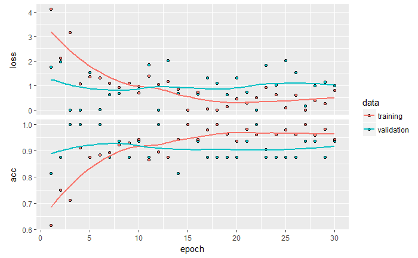

```r
library(graphics)
history1 %>% plot
```

#### Fine tuning

Fine tuning is a process to take a network model that has already been trained for a given task, and make it perform a second similar task. Using a network that has already been designed and trained allows us to take advantage of the feature extraction that happens in the front layers of the network without developing that feature extraction network from scratch.  
Fine-tuning consists of unfreezing a few of the top layers of a frozen model base used for feature extraction, and jointly training both the newly added part of the model (in this case, the fully connected classifier) and these top layers.

```r
base_model_vgg16_fine_tuning <- application_vgg16(
  weights = "imagenet",
  include_top = FALSE
)
```

```r
model_layers_fine_tuning <- base_model_vgg16_fine_tuning$output %>%
  layer_global_average_pooling_2d(trainable = T) %>%
  layer_dense(64, trainable = T) %>%
  layer_activation("relu", trainable = T) %>%
  layer_dropout(0.5, trainable = T) %>%
  layer_dense(2, trainable=T) %>%
  layer_activation("softmax", trainable=T)
```

```r
for (layer in base_model_vgg16_fine_tuning$layers)
  layer$trainable <- FALSE
```

```r
model_fine_tuning <- keras_model(inputs = base_model_vgg16_fine_tuning$input, outputs = model_layers_fine_tuning)
```

```r
unfreeze_weights(model_fine_tuning, from = "block5_conv1") #unfreezing the 3 last layers
```

```r
model_fine_tuning %>% compile(
  loss = "categorical_crossentropy",
  optimizer = optimizer_rmsprop(lr = 0.0001, decay = 1e-6),
  metrics = c("accuracy")
)

history2  <- model_fine_tuning %>% fit_generator(
  train_generator,
  steps_per_epoch = as.integer(train_samples/batch_size),
  epochs = 30,
  validation_data = val_generator,
  validation_steps  = as.integer(val_samples/batch_size),
  verbose = 1
)
```

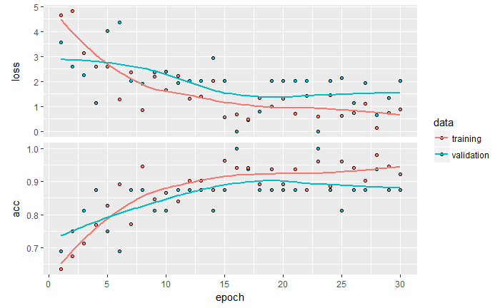

```r
library(graphics)
history2 %>% plot
```

**We reach an validation accuracy of 88% after 30 epochs.**  
It seems that in the fine-tuning approach, the accuracy rate is a little bit **slower to converge**, and finally reaches a **inferior level** than the previous one, obtained with the transfer learning approach.